# 01_19C_DataScienceSalaries_Prediction_Model

### Data Science Salaries 2023 - 추가 분석 2편 : 연봉 예측 모델과 국가별 연봉 지도

### 학습 내용

- 1편([01_19B 추가 분석](https://ldjwj.github.io/dataAnalysis/01_19B_DataScienceSalaries_Analysis_Advanced.html))에서 찾은 연봉 요인을 **예측 모델**로 한 번에 확인하기
- `OneHotEncoder` + `Pipeline`, **KFold 교차검증**(MAE, R²), **log 변환 타깃**, **permutation importance** 익히기
- plotly **choropleth 지도**로 국가별 연봉 중앙값 시각화 (ISO-2 → ISO-3 국가 코드 변환)

### 내용

- 0. 기본 분석 돌아보기 - 무엇을 보완할까?
- 1. 데이터 준비 (1편과 같은 라벨 / 직무 그룹 규칙)
- 2. 기준 모델과 교차검증 설계
- 3. 선형 회귀 vs 랜덤포레스트 (원래 연봉 vs log 연봉)
- 4. 회사 위치를 더 자세히 - 미국/미국 외 vs 상위 국가+기타
- 5. 연봉에 가장 큰 영향을 주는 요인 - permutation importance
- 6. 혼재 변수를 통제한 효과 - 선형 회귀(log) 계수 해석
- 7. 예측 오차 살펴보기
- 8. 국가별 연봉 중앙값 지도 (plotly choropleth)
- 9. 정리

### 0. 기본 분석 돌아보기 - 무엇을 보완할까?

- **기본 EDA**([01_19](https://ldjwj.github.io/dataAnalysis/01_19_DataScienceSalaries_Analysis_2305.html)) : 평균 비교 위주 → 1명, 2명짜리 직무·국가가 1위가 되는 문제
- **추가 분석 1편**([01_19B](https://ldjwj.github.io/dataAnalysis/01_19B_DataScienceSalaries_Analysis_Advanced.html)) : 중앙값 + 표본 수 + 혼재 변수 확인
  - 경력 : 신입 70 → 중급 100 → 시니어 146 → 임원 196 (천 달러, 중앙값)
  - 기업 규모 : 단순 비교는 중기업(140) > 대기업(108.5)이지만 **미국 회사만 보면 145 ≈ 144**
  - 근무 형태 : 하이브리드가 낮아 보인 것은 **79%가 미국 외 회사**이기 때문
  - 같은 직무라도 미국 회사의 연봉 중앙값이 **약 2~2.8배**
- **남은 질문**
  - 1편은 변수를 **2개씩** 나누어 보았다. 여러 변수를 **동시에** 고려하면 어떤 변수가 가장 중요할까?
  - 이 변수들로 연봉을 **얼마나 정확히 예측**할 수 있을까?

### 필수 라이브러리 불러오기

```python
import re
import warnings
import pandas as pd
import numpy as np
import seaborn as sns
import matplotlib.pyplot as plt

from sklearn.model_selection import KFold, cross_validate, train_test_split
from sklearn.preprocessing import OneHotEncoder
from sklearn.compose import ColumnTransformer, TransformedTargetRegressor
from sklearn.pipeline import Pipeline
from sklearn.linear_model import LinearRegression
from sklearn.ensemble import RandomForestRegressor
from sklearn.dummy import DummyRegressor
from sklearn.inspection import permutation_importance
from sklearn.metrics import mean_absolute_error, r2_score

import plotly.graph_objects as go
import plotly.io as pio
pio.renderers.default = 'notebook'   # HTML 파일에 plotly.js가 포함되어 오프라인에서도 동작

warnings.filterwarnings('ignore')

# 한글 폰트 설정
# - koreanize-matplotlib이 설치되어 있으면 OS와 상관없이 나눔고딕을 사용 (pip install koreanize-matplotlib)
# - 없으면 OS에 맞는 기본 한글 폰트를 사용
try:
    import koreanize_matplotlib
except ImportError:
    import platform
    plt.rcParams['font.family'] = {'Windows': 'Malgun Gothic',
                                   'Darwin': 'AppleGothic'}.get(platform.system(), 'NanumGothic')
plt.rcParams['axes.unicode_minus'] = False

sns.set_theme(style='whitegrid', font=plt.rcParams['font.family'])
```

### 1. 데이터 준비

- 1편과 **같은 라벨 매핑**과 **같은 직무 그룹 규칙**을 그대로 사용한다.

```python
file_path = "./data/dataScienceSalaries2023/ds_salaries.csv"
df = pd.read_csv(file_path)

exp_map = {'EN': '신입(EN)', 'MI': '중급(MI)', 'SE': '시니어(SE)', 'EX': '임원(EX)'}
size_map = {'S': '소기업(S)', 'M': '중기업(M)', 'L': '대기업(L)'}
remote_map = {0: '사무실(0%)', 50: '하이브리드(50%)', 100: '완전 원격(100%)'}
emp_map = {'FT': '정규직', 'PT': '파트타임', 'CT': '계약직', 'FL': '프리랜서'}

df['경력'] = df['experience_level'].map(exp_map)
df['기업규모'] = df['company_size'].map(size_map)
df['근무형태'] = df['remote_ratio'].map(remote_map)
df['고용형태'] = df['employment_type'].map(emp_map)
df['회사위치'] = np.where(df['company_location'] == 'US', '미국', '미국 외')
df['연도'] = df['work_year'].astype(str)          # 4개 연도 → 범주로 사용
df['연봉(천달러)'] = df['salary_in_usd'] / 1000

# 1편의 직무 그룹 규칙 (위에서부터 순서대로 판단)
group_rules = [
    ('리더/관리자',      r'Manager|Head|Director|Lead'),
    ('ML/AI·리서치',     r'Machine Learning|\bML\b|\bAI\b|Computer Vision|NLP|Deep Learning|Research|Applied Scientist'),
    ('데이터 엔지니어링', r'Engineer|Architect|ETL|Infrastructure|Developer'),
    ('데이터 분석',      r'Analyst|Analytics|\bBI\b|Business Intelligence'),
    ('데이터 사이언스',   r'Scientist|Science|Modeler'),
]

def job_group(title):
    for name, pattern in group_rules:
        if re.search(pattern, title):
            return name
    return '기타'

df['직무그룹'] = df['job_title'].apply(job_group)

df['직무그룹'].value_counts()
```

```
직무그룹
데이터 엔지니어링    1336
데이터 사이언스      886
데이터 분석        683
ML/AI·리서치     649
리더/관리자        182
기타             19
Name: count, dtype: int64
```

- 한줄 확인 : 1편과 동일하게 데이터 엔지니어링 1,336명, 데이터 사이언스 886명, 데이터 분석 683명, ML/AI·리서치 649명, 리더/관리자 182명, 기타 19명으로 나뉘었다.

#### 1-1. 타깃(연봉) 분포 - 왜 log 변환을 비교할까?

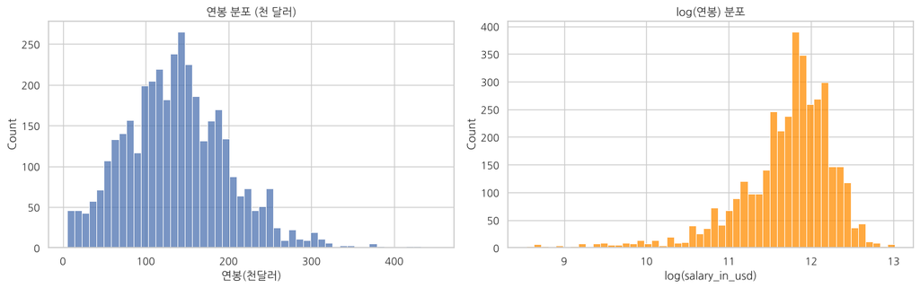

```
왜도(skew) - 원래 연봉 : 0.54
왜도(skew) - log 연봉 : -1.61
```

```python
fig, axes = plt.subplots(1, 2, figsize=(14, 4.5))
sns.histplot(df['연봉(천달러)'], bins=50, ax=axes[0])
axes[0].set_title('연봉 분포 (천 달러)')
sns.histplot(np.log(df['salary_in_usd']), bins=50, ax=axes[1], color='darkorange')
axes[1].set_title('log(연봉) 분포')
axes[1].set_xlabel('log(salary_in_usd)')
plt.tight_layout()
plt.show()

print('왜도(skew) - 원래 연봉 :', round(df['salary_in_usd'].skew(), 2))
print('왜도(skew) - log 연봉 :', round(np.log(df['salary_in_usd']).skew(), 2))
```

- 한줄 확인 : 원래 연봉의 왜도는 0.54로 오른쪽 꼬리가 크지 않은데, log 변환하면 -1.61로 오히려 **왼쪽 꼬리**(연봉이 매우 낮은 소수)가 길어진다.
  - 즉 log 변환이 이 데이터에서 무조건 좋다고 할 수 없으므로, **두 방식 모두 교차검증으로 비교**한다.
  - 연봉의 차이는 "몇 달러 더"보다 **"몇 % 더"** 로 나타나는 경우가 많다(예: 미국 회사는 약 2배). log 변환하면 곱셈 효과가 덧셈 효과로 바뀌어 **선형 회귀에 잘 맞을 수 있다.**

### 2. 기준 모델과 교차검증 설계

- **입력 변수(7개)** : 경력, 직무그룹, 회사위치, 기업규모, 근무형태, 고용형태, 연도 → 모두 범주형이므로 **OneHotEncoder**로 변환
- **Pipeline** : 전처리(OneHot) + 모델을 하나로 묶으면 교차검증의 각 fold 안에서 전처리가 따로 학습되어 정보 누수가 없다.
- **KFold 5-fold**(shuffle, random_state=42)로 **MAE(천 달러)** 와 **R²** 를 측정
- log 타깃 모델은 `TransformedTargetRegressor`로 학습은 log(연봉), 예측값은 다시 원래 달러로 되돌려 **같은 단위의 MAE**로 비교한다.
- 비교 기준 : 모든 사람에게 **중앙값 하나만** 예측하는 `DummyRegressor`

```python
features = ['경력', '직무그룹', '회사위치', '기업규모', '근무형태', '고용형태', '연도']
X = df[features]
y = df['연봉(천달러)']

kf = KFold(n_splits=5, shuffle=True, random_state=42)
scoring = {'MAE': 'neg_mean_absolute_error', 'R2': 'r2'}

def make_model(model, cols, log_target=False):
    """OneHot 전처리 + 모델 Pipeline (log_target=True면 log(연봉)으로 학습)"""
    pre = ColumnTransformer([('onehot', OneHotEncoder(handle_unknown='ignore'), cols)])
    pipe = Pipeline([('pre', pre), ('model', model)])
    if log_target:
        return TransformedTargetRegressor(regressor=pipe, func=np.log, inverse_func=np.exp)
    return pipe

def cv_score(name, model, X, y):
    s = cross_validate(model, X, y, cv=kf, scoring=scoring)
    return {'모델': name,
            'MAE(천달러)': -s['test_MAE'].mean(), 'MAE 표준편차': s['test_MAE'].std(),
            'R²': s['test_R2'].mean(), 'R² 표준편차': s['test_R2'].std()}

base = cv_score('기준(중앙값 예측)', DummyRegressor(strategy='median'), X, y)
pd.DataFrame([base]).round(3)
```

|  | 모델 | MAE(천달러) | MAE 표준편차 | R² | R² 표준편차 |
| --- | --- | --- | --- | --- | --- |
| 0 | 기준(중앙값 예측) | 49.029 | 0.639 | -0.004 | 0.003 |

- 한줄 확인 : 모든 사람에게 중앙값만 예측하면 MAE는 **약 49.0천 달러**, R²는 약 0(-0.004)이다. 이 값보다 얼마나 좋아지는지가 모델의 실력이다.

### 3. 선형 회귀 vs 랜덤포레스트 (원래 연봉 vs log 연봉)

- 랜덤포레스트는 과적합을 줄이기 위해 `min_samples_leaf=5`, 나무 200개, `n_jobs=2`로 설정

```python
rf = lambda: RandomForestRegressor(n_estimators=200, min_samples_leaf=5, random_state=42, n_jobs=2)

models = {
    '선형 회귀':          make_model(LinearRegression(), features),
    '선형 회귀 (log)':    make_model(LinearRegression(), features, log_target=True),
    '랜덤포레스트':        make_model(rf(), features),
    '랜덤포레스트 (log)':  make_model(rf(), features, log_target=True),
}

results = [base] + [cv_score(name, m, X, y) for name, m in models.items()]
result_df = pd.DataFrame(results).set_index('모델').round(3)
result_df
```

| 모델 | MAE(천달러) | MAE 표준편차 | R² | R² 표준편차 |
| --- | --- | --- | --- | --- |
| 기준(중앙값 예측) | 49.029 | 0.639 | -0.004 | 0.003 |
| 선형 회귀 | 37.401 | 0.832 | 0.387 | 0.040 |
| 선형 회귀 (log) | 37.046 | 1.087 | 0.361 | 0.051 |
| 랜덤포레스트 | 36.952 | 0.992 | 0.398 | 0.040 |
| 랜덤포레스트 (log) | 36.427 | 1.056 | 0.382 | 0.046 |

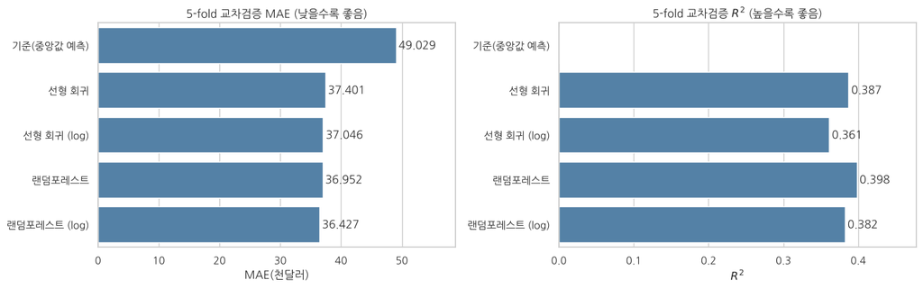

```python
fig, axes = plt.subplots(1, 2, figsize=(14, 4.5))
plot_df = result_df.reset_index()
for ax, col, title in [(axes[0], 'MAE(천달러)', 'MAE (낮을수록 좋음)'), (axes[1], 'R²', '$R^2$ (높을수록 좋음)')]:
    sns.barplot(data=plot_df, y='모델', x=col, color='steelblue', ax=ax)
    ax.bar_label(ax.containers[0], fmt='%.3f', padding=3)
    ax.set_title(f'5-fold 교차검증 {title}')
    ax.set_ylabel('')
    ax.set_xlabel(col.replace('R²', '$R^2$'))
    ax.set_xlim(0, plot_df[col].max() * 1.2)
plt.tight_layout()
plt.show()
```

### 4. 회사 위치를 더 자세히 - 미국/미국 외 vs 상위 국가+기타

- 1편에서 10명 이상인 국가는 13개국이었다. 이 13개국은 그대로, 나머지는 `기타`로 묶은 **국가그룹** 변수를 만들어 비교한다.

```python
country_cnt = df['company_location'].value_counts()
top_countries = country_cnt[country_cnt >= 10].index
df['국가그룹'] = df['company_location'].where(df['company_location'].isin(top_countries), '기타')
print('국가그룹 :', df['국가그룹'].nunique(), '개 범주 /', '기타 인원 :', (df['국가그룹'] == '기타').sum(), '명')

features2 = ['경력', '직무그룹', '국가그룹', '기업규모', '근무형태', '고용형태', '연도']
X2 = df[features2]

compare = [
    cv_score('선형 회귀 (log) - 미국/미국 외', make_model(LinearRegression(), features, True), X, y),
    cv_score('선형 회귀 (log) - 상위 13개국+기타', make_model(LinearRegression(), features2, True), X2, y),
    cv_score('랜덤포레스트 (log) - 미국/미국 외', make_model(rf(), features, True), X, y),
    cv_score('랜덤포레스트 (log) - 상위 13개국+기타', make_model(rf(), features2, True), X2, y),
]
pd.DataFrame(compare).set_index('모델').round(3)
```

```
국가그룹 : 14 개 범주 / 기타 인원 : 151 명
```

| 모델 | MAE(천달러) | MAE 표준편차 | R² | R² 표준편차 |
| --- | --- | --- | --- | --- |
| 선형 회귀 (log) - 미국/미국 외 | 37.046 | 1.087 | 0.361 | 0.051 |
| 선형 회귀 (log) - 상위 13개국+기타 | 35.752 | 1.062 | 0.393 | 0.052 |
| 랜덤포레스트 (log) - 미국/미국 외 | 36.427 | 1.056 | 0.382 | 0.046 |
| 랜덤포레스트 (log) - 상위 13개국+기타 | 35.643 | 0.945 | 0.398 | 0.047 |

- 한줄 확인
  - 회사위치를 **상위 13개국+기타**로 자세히 나누면 두 모델 모두 좋아진다.
    - 선형 회귀(log) : MAE 37.046 → **35.752**, R² 0.361 → **0.393**
    - 랜덤포레스트(log) : MAE 36.427 → **35.643**, R² 0.382 → **0.398**
  - "미국 외"는 캐나다(중앙값 120)부터 인도(18.3)까지 차이가 매우 큰 집단이기 때문이다.
  - 다만 개선 폭은 MAE 약 1천 달러로 크지 않으므로, 아래 해석에서는 **이해하기 쉬운 미국/미국 외 버전**을 사용한다.

### 5. 연봉에 가장 큰 영향을 주는 요인 - permutation importance

- **permutation importance** : 한 변수의 값을 무작위로 섞었을 때 예측 오차(MAE)가 **얼마나 커지는지**로 중요도를 잰다.
  - 섞어도 오차가 그대로면 → 모델이 그 변수를 거의 쓰지 않는 것
  - Pipeline에 **원래 변수(OneHot 이전)** 를 넣고 섞기 때문에, 더미 변수 여러 개가 아닌 **변수 단위**로 중요도를 볼 수 있다.
- 학습 80% / 평가 20%로 나눈 뒤, **평가 데이터**에서 10번 반복해 계산

```python
final_features = features   # 해석이 쉬운 미국/미국 외 버전 사용
X_tr, X_te, y_tr, y_te = train_test_split(df[final_features], y, test_size=0.2, random_state=42)

imp_list = []
for name, m in [('선형 회귀 (log)', make_model(LinearRegression(), final_features, True)),
                ('랜덤포레스트 (log)', make_model(rf(), final_features, True))]:
    m.fit(X_tr, y_tr)
    pred = m.predict(X_te)
    print(f'{name:12s} 평가 데이터 MAE : {mean_absolute_error(y_te, pred):.1f}천 달러, R² : {r2_score(y_te, pred):.3f}')
    r = permutation_importance(m, X_te, y_te, scoring='neg_mean_absolute_error',
                               n_repeats=10, random_state=42, n_jobs=2)
    imp_list.append(pd.DataFrame({'변수': final_features, '모델': name,
                                  'MAE 증가(천달러)': r.importances_mean, '표준편차': r.importances_std}))

imp = pd.concat(imp_list)
imp_table = imp.pivot(index='변수', columns='모델', values='MAE 증가(천달러)')
imp_table = imp_table.sort_values('랜덤포레스트 (log)', ascending=False).round(2)
imp_table
```

```
선형 회귀 (log)  평가 데이터 MAE : 38.0천 달러, R² : 0.360
```

```
랜덤포레스트 (log) 평가 데이터 MAE : 37.1천 달러, R² : 0.376
```

| 모델 변수 | 랜덤포레스트 (log) | 선형 회귀 (log) |
| --- | --- | --- |
| 회사위치 | 9.64 | 10.31 |
| 경력 | 6.55 | 5.25 |
| 직무그룹 | 5.43 | 4.57 |
| 근무형태 | 1.00 | -0.01 |
| 연도 | 0.56 | 0.07 |
| 기업규모 | 0.34 | 0.11 |
| 고용형태 | 0.17 | 0.34 |

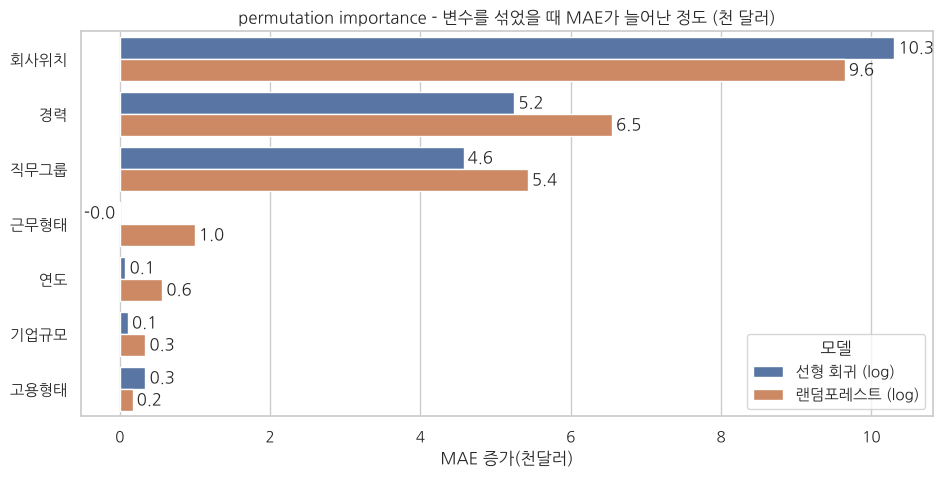

```python
fig, ax = plt.subplots(figsize=(11, 5))
sns.barplot(data=imp, y='변수', x='MAE 증가(천달러)', hue='모델', order=imp_table.index, ax=ax)
for c in ax.containers:
    ax.bar_label(c, fmt='%.1f', padding=3)
ax.set_title('permutation importance - 변수를 섞었을 때 MAE가 늘어난 정도 (천 달러)')
ax.set_ylabel('')
plt.show()
```

- 한줄 확인
  - 두 모델 모두 **회사위치(9.64~10.31) > 경력(5.25~6.55) > 직무그룹(4.57~5.43)** 순으로 중요하다. (섞었을 때 MAE가 늘어난 천 달러)
  - 근무형태, 연도, 기업규모, 고용형태는 섞어도 MAE가 **1천 달러 이하**로만 늘어난다. → 위 세 변수를 알면 나머지는 예측에 거의 도움이 되지 않는다.
  - 1편에서 기업규모·근무형태의 연봉 차이가 크게 보였던 것은, 대부분 **회사위치(혼재 변수)** 때문이었다는 결론과 일치한다.
  - 참고 : 평가 데이터(20%)에서 선형 회귀(log) MAE 38.0, 랜덤포레스트(log) MAE 37.1

### 6. 혼재 변수를 통제한 효과 - 선형 회귀(log) 계수 해석

- log(연봉) 선형 회귀의 계수 b는 **기준 범주 대비 연봉이 약 (e^b − 1) × 100 % 다르다**는 뜻이다.
- 기준 범주 : 시니어(SE), 데이터 엔지니어링, 미국, 중기업(M), 사무실(0%), 정규직, 2023년
- **모든 변수를 동시에 넣었기 때문에**, 예를 들어 기업 규모의 계수는 "회사 위치·경력 등이 같을 때"의 차이이다. → 1편에서 표를 나누어 확인한 혼재 변수 통제를 모델이 한 번에 해 준다.

```python
baseline = {'경력': '시니어(SE)', '직무그룹': '데이터 엔지니어링', '회사위치': '미국', '기업규모': '중기업(M)',
            '근무형태': '사무실(0%)', '고용형태': '정규직', '연도': '2023'}

# 기준 범주를 첫 번째로 두고, OneHot의 drop='first'로 기준 범주를 제외
cats = [[baseline[c]] + sorted(set(df[c]) - {baseline[c]}) for c in features]
pre = ColumnTransformer([('onehot', OneHotEncoder(categories=cats, drop='first'), features)])
lin = Pipeline([('pre', pre), ('model', LinearRegression())])
lin.fit(df[features], np.log(df['salary_in_usd']))

names = lin.named_steps['pre'].get_feature_names_out()
coef = pd.DataFrame({'항목': [n.replace('onehot__', '') for n in names],
                     '계수': lin.named_steps['model'].coef_})
coef['연봉 차이(%)'] = (np.exp(coef['계수']) - 1) * 100
coef['변수'] = coef['항목'].str.split('_').str[0]
coef['인원수'] = [ (df[v] == k.split('_', 1)[1]).sum() for v, k in zip(coef['변수'], coef['항목'])]
coef.round({'계수': 3, '연봉 차이(%)': 1})
```

|  | 항목 | 계수 | 연봉 차이(%) | 변수 | 인원수 |
| --- | --- | --- | --- | --- | --- |
| 0 | 경력_신입(EN) | -0.537 | -41.5 | 경력 | 320 |
| 1 | 경력_임원(EX) | 0.254 | 29.0 | 경력 | 114 |
| 2 | 경력_중급(MI) | -0.215 | -19.3 | 경력 | 805 |
| 3 | 직무그룹_ML/AI·리서치 | 0.191 | 21.0 | 직무그룹 | 649 |
| 4 | 직무그룹_기타 | -0.196 | -17.8 | 직무그룹 | 19 |
| 5 | 직무그룹_데이터 분석 | -0.233 | -20.7 | 직무그룹 | 683 |
| 6 | 직무그룹_데이터 사이언스 | 0.026 | 2.6 | 직무그룹 | 886 |
| 7 | 직무그룹_리더/관리자 | 0.144 | 15.5 | 직무그룹 | 182 |
| 8 | 회사위치_미국 외 | -0.671 | -48.9 | 회사위치 | 715 |
| 9 | 기업규모_대기업(L) | -0.021 | -2.1 | 기업규모 | 454 |
| 10 | 기업규모_소기업(S) | -0.250 | -22.2 | 기업규모 | 148 |
| 11 | 근무형태_완전 원격(100%) | 0.000 | 0.0 | 근무형태 | 1643 |
| 12 | 근무형태_하이브리드(50%) | -0.032 | -3.2 | 근무형태 | 189 |
| 13 | 고용형태_계약직 | -0.437 | -35.4 | 고용형태 | 10 |
| 14 | 고용형태_파트타임 | -0.643 | -47.4 | 고용형태 | 17 |
| 15 | 고용형태_프리랜서 | -0.517 | -40.3 | 고용형태 | 10 |
| 16 | 연도_2020 | -0.126 | -11.9 | 연도 | 76 |
| 17 | 연도_2021 | -0.160 | -14.8 | 연도 | 230 |
| 18 | 연도_2022 | -0.054 | -5.2 | 연도 | 1664 |

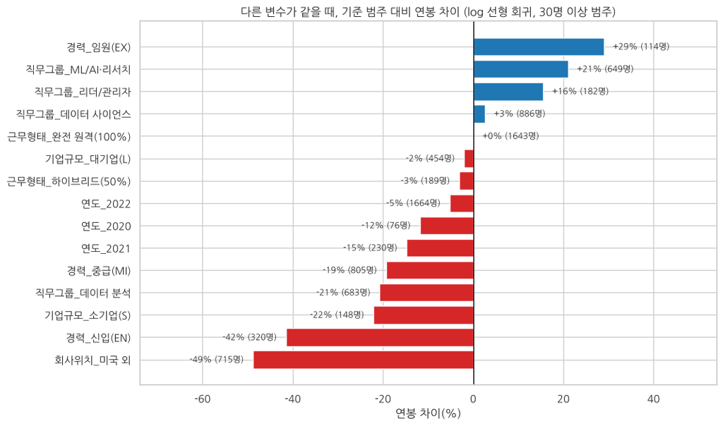

```python
plot_coef = coef[coef['인원수'] >= 30].sort_values('연봉 차이(%)')
colors = np.where(plot_coef['연봉 차이(%)'] > 0, 'tab:blue', 'tab:red')

fig, ax = plt.subplots(figsize=(11, 7))
ax.barh(plot_coef['항목'], plot_coef['연봉 차이(%)'], color=colors)
for i, (v, n) in enumerate(zip(plot_coef['연봉 차이(%)'], plot_coef['인원수'])):
    ax.text(v + (2 if v > 0 else -2), i, f'{v:+.0f}% ({n}명)', va='center', ha='left' if v > 0 else 'right', fontsize=9)
ax.axvline(0, color='black', lw=1)
ax.set_xlim(plot_coef['연봉 차이(%)'].min() - 25, plot_coef['연봉 차이(%)'].max() + 25)
ax.set_title('다른 변수가 같을 때, 기준 범주 대비 연봉 차이 (log 선형 회귀, 30명 이상 범주)')
ax.set_xlabel('연봉 차이(%)')
plt.show()
```

- 한줄 확인
  - **미국 외 회사 -49%** : 다른 조건이 같아도 연봉이 약 절반 → 가장 큰 효과
  - 경력 : 시니어 대비 신입 **-42%**, 중급 **-19%**, 임원 **+29%**
  - 직무그룹 : 데이터 엔지니어링 대비 ML/AI·리서치 **+21%**, 리더/관리자 **+16%**, 데이터 분석 **-21%**
  - 기업규모 : 중기업 대비 대기업 **-2%**(거의 차이 없음), 소기업 **-22%**
  - 근무형태 : 사무실 대비 완전 원격 **0%**, 하이브리드 **-3%** → 근무 형태 자체의 효과는 거의 없다.
  - 고용형태(계약직·파트타임·프리랜서)는 -35~-47%이지만 각 10~17명이라 그래프에서는 제외했다.

#### 6-1. 1편의 단순 비교 vs 모델로 통제한 비교

```python
def simple_diff(col, a, b):
    """단순 중앙값 비교 : a가 b보다 몇 % 높은가"""
    m = df.groupby(col)['salary_in_usd'].median()
    return (m[a] / m[b] - 1) * 100

def model_diff(col, a, b):
    """모델 계수 비교 : 다른 변수가 같을 때 a가 b보다 몇 % 높은가"""
    get = lambda k: 0 if k == baseline[col] else coef.loc[coef['항목'] == f'{col}_{k}', '계수'].iloc[0]
    return (np.exp(get(a) - get(b)) - 1) * 100

pairs = [('기업규모', '대기업(L)', '중기업(M)'), ('기업규모', '소기업(S)', '중기업(M)'),
         ('근무형태', '하이브리드(50%)', '사무실(0%)'), ('근무형태', '완전 원격(100%)', '사무실(0%)'),
         ('회사위치', '미국 외', '미국'), ('경력', '임원(EX)', '신입(EN)')]
pd.DataFrame([{'비교': f'{a} vs {b}', '단순 중앙값 비교(%)': simple_diff(c, a, b),
               '모델로 통제한 차이(%)': model_diff(c, a, b)} for c, a, b in pairs]).round(1)
```

|  | 비교 | 단순 중앙값 비교(%) | 모델로 통제한 차이(%) |
| --- | --- | --- | --- |
| 0 | 대기업(L) vs 중기업(M) | -22.5 | -2.1 |
| 1 | 소기업(S) vs 중기업(M) | -55.6 | -22.2 |
| 2 | 하이브리드(50%) vs 사무실(0%) | -54.6 | -3.2 |
| 3 | 완전 원격(100%) vs 사무실(0%) | -3.3 | 0.0 |
| 4 | 미국 외 vs 미국 | -55.2 | -48.9 |
| 5 | 임원(EX) vs 신입(EN) | 180.0 | 120.6 |

- 한줄 확인
  - **대기업 vs 중기업** : 단순 비교 -22.5% → 통제 후 **-2.1%** (1편 결론 "미국 회사만 보면 대기업 ≈ 중기업"과 일치)
  - **하이브리드 vs 사무실** : 단순 비교 -54.6% → 통제 후 **-3.2%** (1편 결론 "하이브리드가 낮은 것은 미국 외 회사 비율 때문"과 일치)
  - **소기업 vs 중기업** : -55.6% → -22.2%로 줄었지만 여전히 낮다. (1편 : 소기업은 미국/미국 외 모두 가장 낮음)
  - **미국 외 vs 미국** : -55.2% → -48.9%로 통제 후에도 거의 그대로 → 회사위치는 다른 변수에 가려진 효과가 아니라 **실제로 큰 요인**
  - 임원 vs 신입 : +180% → +120.6%. 임원은 미국·대기업·리더 직무가 많아 단순 비교가 차이를 부풀린다.

### 7. 예측 오차 살펴보기

- 랜덤포레스트(log) 모델의 평가 데이터 예측값과 실제값 비교

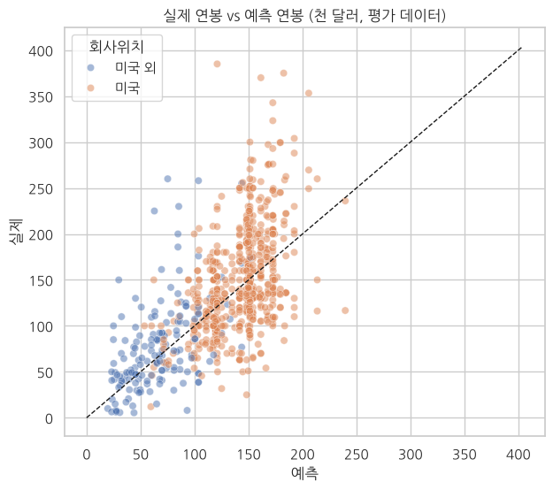

| 경력 | 인원수 | MAE | 중앙값오차 |
| --- | --- | --- | --- |
| 신입(EN) | 67 | 27.8 | 21.2 |
| 중급(MI) | 157 | 28.2 | 22.8 |
| 시니어(SE) | 504 | 40.1 | 30.0 |
| 임원(EX) | 23 | 61.2 | 60.3 |

```python
best = make_model(rf(), final_features, True).fit(X_tr, y_tr)
res = X_te.copy()
res['실제'] = y_te
res['예측'] = best.predict(X_te)
res['절대오차'] = (res['실제'] - res['예측']).abs()

fig, ax = plt.subplots(figsize=(7, 6))
sns.scatterplot(data=res, x='예측', y='실제', hue='회사위치',
                alpha=0.5, ax=ax)
lim = [0, res[['실제', '예측']].max().max() * 1.05]
ax.plot(lim, lim, 'k--', lw=1)
ax.set_title('실제 연봉 vs 예측 연봉 (천 달러, 평가 데이터)')
plt.show()

(res.groupby('경력')['절대오차'].agg(인원수='count', MAE='mean', 중앙값오차='median')
    .reindex(exp_map.values()).round(1))
```

```python
# 실제 연봉 구간별 평균 오차 (예측 - 실제) : 음수면 실제보다 낮게 예측
res['오차'] = res['예측'] - res['실제']
res['실제 연봉 구간'] = pd.cut(res['실제'], bins=[0, 50, 100, 150, 200, 250, 500])
res.groupby('실제 연봉 구간', observed=True)['오차'].agg(인원수='count', 평균오차='mean').round(1)
```

| 실제 연봉 구간 | 인원수 | 평균오차 |
| --- | --- | --- |
| (0, 50] | 62 | 21.6 |
| (50, 100] | 164 | 20.6 |
| (100, 150] | 268 | 9.1 |
| (150, 200] | 147 | -28.2 |
| (200, 250] | 77 | -67.5 |
| (250, 500] | 33 | -124.7 |

- 한줄 확인
  - 경력별 MAE : 신입 27.8, 중급 28.2, 시니어 40.1, **임원 61.2**천 달러 → 연봉이 높은 그룹일수록 오차가 크다.
  - 실제 연봉 구간별로 보면 **250천 달러 초과는 평균 124.7천 달러 낮게**, 200~250은 67.5 낮게 예측하고, 100천 달러 이하는 약 21 높게 예측한다.
  - 범주형 변수 7개로는 "같은 조건 안의 개인 차이"를 알 수 없어 예측이 **가운데로 몰린다.** (그래프에서 예측값이 약 250 이하에 모여 있음)
  - 정확도를 높이려면 회사명, 세부 직무, 기술 스택, 도시 등 추가 정보가 필요하다.

### 8. 국가별 연봉 중앙값 지도 (plotly choropleth)

- 데이터의 국가 코드는 **ISO-2**(예: `US`), plotly 지도는 **ISO-3**(예: `USA`)를 사용하므로 변환표가 필요하다.
  - `pycountry` 라이브러리로도 변환할 수 있지만, 여기서는 설치 없이 실행되도록 데이터에 있는 72개국의 변환표를 직접 만든다.
- **10명 이상 국가는 색으로 강조**, 10명 미만 국가는 회색으로 표시하고, 마우스를 올리면 **인원수와 중앙값**이 보인다.

```python
iso2_to_iso3 = {
    'AE': 'ARE', 'AL': 'ALB', 'AM': 'ARM', 'AR': 'ARG', 'AS': 'ASM', 'AT': 'AUT', 'AU': 'AUS', 'BA': 'BIH',
    'BE': 'BEL', 'BO': 'BOL', 'BR': 'BRA', 'BS': 'BHS', 'CA': 'CAN', 'CF': 'CAF', 'CH': 'CHE', 'CL': 'CHL',
    'CN': 'CHN', 'CO': 'COL', 'CR': 'CRI', 'CZ': 'CZE', 'DE': 'DEU', 'DK': 'DNK', 'DZ': 'DZA', 'EE': 'EST',
    'EG': 'EGY', 'ES': 'ESP', 'FI': 'FIN', 'FR': 'FRA', 'GB': 'GBR', 'GH': 'GHA', 'GR': 'GRC', 'HK': 'HKG',
    'HN': 'HND', 'HR': 'HRV', 'HU': 'HUN', 'ID': 'IDN', 'IE': 'IRL', 'IL': 'ISR', 'IN': 'IND', 'IQ': 'IRQ',
    'IR': 'IRN', 'IT': 'ITA', 'JP': 'JPN', 'KE': 'KEN', 'LT': 'LTU', 'LU': 'LUX', 'LV': 'LVA', 'MA': 'MAR',
    'MD': 'MDA', 'MK': 'MKD', 'MT': 'MLT', 'MX': 'MEX', 'MY': 'MYS', 'NG': 'NGA', 'NL': 'NLD', 'NZ': 'NZL',
    'PH': 'PHL', 'PK': 'PAK', 'PL': 'POL', 'PR': 'PRI', 'PT': 'PRT', 'RO': 'ROU', 'RU': 'RUS', 'SE': 'SWE',
    'SG': 'SGP', 'SI': 'SVN', 'SK': 'SVK', 'TH': 'THA', 'TR': 'TUR', 'UA': 'UKR', 'US': 'USA', 'VN': 'VNM',
}

country = (df.groupby('company_location')['연봉(천달러)']
             .agg(인원수='count', 중앙값='median').reset_index())
country['iso3'] = country['company_location'].map(iso2_to_iso3)
print('변환되지 않은 국가 코드 :', country.loc[country['iso3'].isna(), 'company_location'].tolist())
print('전체 국가 수 :', len(country), '/ 10명 이상 국가 수 :', (country['인원수'] >= 10).sum())
country.sort_values('인원수', ascending=False).head()
```

```
변환되지 않은 국가 코드 : []
전체 국가 수 : 72 / 10명 이상 국가 수 : 13
```

|  | company_location | 인원수 | 중앙값 | iso3 |
| --- | --- | --- | --- | --- |
| 70 | US | 3040 | 145.000 | USA |
| 28 | GB | 172 | 79.513 | GBR |
| 12 | CA | 87 | 120.000 | CAN |
| 25 | ES | 77 | 47.280 | ESP |
| 38 | IN | 58 | 18.276 | IND |

```python
country['hover'] = (country['company_location'] + ' (' + country['iso3'] + ')<br>'
                    + '인원수 : ' + country['인원수'].astype(str) + '명<br>'
                    + '연봉 중앙값 : ' + country['중앙값'].round(1).astype(str) + '천 달러')
big = country[country['인원수'] >= 10]
small = country[country['인원수'] < 10]

fig = go.Figure()
# 10명 미만 : 회색 (표본이 적어 참고용)
fig.add_trace(go.Choropleth(
    locations=small['iso3'], z=[1] * len(small), text=small['hover'], hoverinfo='text',
    colorscale=[[0, '#d9d9d9'], [1, '#d9d9d9']], showscale=False, marker_line_color='white',
    name='10명 미만'))
# 10명 이상 : 연봉 중앙값으로 색칠
fig.add_trace(go.Choropleth(
    locations=big['iso3'], z=big['중앙값'], text=big['hover'], hoverinfo='text',
    colorscale='YlGnBu', marker_line_color='black', marker_line_width=0.8,
    colorbar=dict(title='연봉 중앙값<br>(천 달러)'), name='10명 이상'))

fig.update_layout(title='회사 위치별 연봉 중앙값 (색 : 10명 이상 국가, 회색 : 10명 미만 국가)',
                  geo=dict(showframe=False, projection_type='natural earth'),
                  height=520, margin=dict(l=10, r=10, t=60, b=10))
fig.show()
```

[interactive chart not shown]

- 한줄 확인
  - ISO-2 → ISO-3 변환표로 72개국이 모두 변환되었고, 10명 이상인 국가는 **13개국**이다.
  - 색이 칠해진 13개국 중 **미국(145, 3,040명)과 캐나다(120, 87명)** 가 가장 진하고, 유럽은 약 47~80, 인도는 18.3으로 가장 낮다. (천 달러, 중앙값)
  - 회색 국가(10명 미만)는 마우스를 올려 인원수를 확인한 뒤 참고만 한다. 예 : 이스라엘(IL)은 2명
  - 싱가포르, 홍콩, 몰타 등 아주 작은 나라는 지도 해상도 때문에 보이지 않을 수 있다.

### 9. 정리

| 질문 | 기본 분석 (EDA, 1편) | 추가 분석 2편 결과 |
| --- | --- | --- |
| 이 변수들로 연봉을 얼마나 예측할 수 있을까? | - | 5-fold 교차검증 MAE **약 36.4~37.4천 달러**(기준 49.0), R² **약 0.36~0.40** |
| 선형 회귀 vs 랜덤포레스트? | - | 차이는 MAE 1천 달러 이내. 랜덤포레스트(log)가 MAE 36.427로 가장 낮음 |
| log 변환 타깃은 효과가 있을까? | - | MAE는 조금 감소(예: 36.952 → 36.427), R²는 조금 감소(0.398 → 0.382) |
| 회사 위치를 자세히 나누면? | 미국 / 미국 외 | 상위 13개국+기타로 나누면 MAE 약 0.8~1.3천 달러 감소, R² 최대 0.398 |
| 연봉에 가장 큰 영향을 주는 요인은? | 1편 : 같은 직무라도 미국이 약 2~2.8배 | permutation importance **회사위치 > 경력 > 직무그룹**, 나머지 4개 변수는 1천 달러 이하 |
| 대기업 vs 중기업 | 단순 비교 -22.5% | 다른 변수 통제 후 **-2.1%** (1편 혼재 변수 결론과 일치) |
| 하이브리드 vs 사무실 | 단순 비교 -54.6% | 다른 변수 통제 후 **-3.2%** (1편 혼재 변수 결론과 일치) |
| 국가별 연봉을 한눈에 보려면? | 국가 코드 표 | choropleth 지도 : 10명 이상 13개국 강조, 미국 145 · 캐나다 120 · 인도 18.3 |

#### 배운 점

- `OneHotEncoder` + `Pipeline`으로 전처리와 모델을 묶으면 **교차검증에서도 정보 누수 없이** 공정하게 비교할 수 있다.
- **permutation importance**는 원래 변수 단위로 중요도를 보여 주어, 더미 변수가 많은 범주형 데이터에서 해석하기 쉽다.
- 여러 변수를 동시에 넣은 **log 선형 회귀의 계수**는 "다른 조건이 같을 때"의 % 차이이므로, 혼재 변수를 표로 일일이 나누지 않고도 통제할 수 있다.
- log 변환은 항상 좋은 것이 아니라 **평가 지표(MAE / R²)에 따라 결과가 다르므로** 교차검증으로 확인해야 한다.

#### 다음에 해 볼 분석

- 상위 국가 × 경력 같은 **상호작용 변수** 추가, `GradientBoosting` 등 다른 모델과 비교
- 예측 구간(예: 분위수 회귀)으로 "이 조건이면 연봉이 대략 어느 범위인지" 제시하기